# Final Project: BS 849

Irene Park, Megan Finke, Bhavya Vadavalli, Annie Goodridge

2024-03-15

## Setup

```r
#Loading packages and data
library("curl") #to pull data set
library("rjags")
library("coda")
library("formatR")
library("dplyr")
library("tidyr")
tics.data.2021 <- read.csv("tics.data.2021.csv")
```

Before we began our analysis, we cleaned and manipulated the data set so that it was usable for the JAGS code. We recoded Yes/No dichotomous variables such that “Yes” was 1, and “No” was 0. For MC.Asprin, we removed NA values. For other variables with NA values, we chose to handle them through imputation at later stages rather than directly removing NA values.

```r
# Select baseline observations and variables of interest
baseline_data <- tics.data.2021 %>%
  filter(!is.na(TICS01)) %>%
  select(ID, ptype, Age.at.Enrollment, Age01, BMI, SH.Ever.Smoked., MC.Aspirin, MC.Stroke, MC.Diabetes.Mellitus, MC.HTN, MC.Coronary.Artery.Disease, MC.Cancer, MC.Heart.Attack, Years.of.Education, TICS01)

# Recode "yes" and "no" variables to 1 and 0, handling missing values
baseline_data <- baseline_data %>%
  mutate(SH.Ever.Smoked. = if_else(SH.Ever.Smoked. == "Yes", 1, if_else(SH.Ever.Smoked. == "No", 0, NA_integer_)),
         MC.Aspirin = if_else(MC.Aspirin == "Yes", 1, if_else(MC.Aspirin == "No", 0, NA_integer_)),
         MC.Stroke = if_else(MC.Stroke == "Yes", 1, if_else(MC.Stroke == "No", 0, NA_integer_)),
         MC.Diabetes.Mellitus = if_else(MC.Diabetes.Mellitus == "Yes", 1, if_else(MC.Diabetes.Mellitus == "No", 0, NA_integer_)),
         MC.HTN = if_else(MC.HTN == "Yes", 1, if_else(MC.HTN == "No", 0, NA_integer_)),
         MC.Coronary.Artery.Disease = if_else(MC.Coronary.Artery.Disease == "Yes", 1, if_else(MC.Coronary.Artery.Disease == "No", 0, NA_integer_)),
         MC.Cancer = if_else(MC.Cancer == "Yes", 1, if_else(MC.Cancer == "No", 0, NA_integer_)),
         MC.Heart.Attack = if_else(MC.Heart.Attack == "Yes", 1, if_else(MC.Heart.Attack == "No", 0, NA_integer_)))

# Remove observations where MC.Aspirin is NA
baseline_data<- baseline_data[!is.na(baseline_data$MC.Aspirin), ]

head(baseline_data)
```

```
##   ID ptype Age.at.Enrollment Age01      BMI SH.Ever.Smoked. MC.Aspirin
## 1  1     1                64    70 22.96386               0          1
## 2  2     1                70    76       NA               0          0
## 3  3     1                69    74 30.58906               0          0
## 4  4     1                64    69 21.99409               0          1
## 5  5     1                61    67 25.55509               0          1
## 6  6     1                77    82 20.17747               1          0
##   MC.Stroke MC.Diabetes.Mellitus MC.HTN MC.Coronary.Artery.Disease MC.Cancer
## 1         0                    0      1                          0         1
## 2         0                    0      1                          0         0
## 3         0                    0      1                          0         1
## 4         0                    0      1                          0         1
## 5         0                    0      0                          0         0
## 6         0                    0      0                          0         1
##   MC.Heart.Attack Years.of.Education TICS01
## 1               0               16.0     12
## 2               0               19.0     17
## 3               0               17.0     15
## 4               0               19.0     11
## 5               0               19.5     17
## 6               0               18.0     13
```

```r
# Using summary() function
summary(baseline_data)
```

```
##        ID            ptype        Age.at.Enrollment     Age01
##  Min.   :  1.0   Min.   :0.0000   Min.   :45.0      Min.   :47.00
##  1st Qu.:212.5   1st Qu.:0.0000   1st Qu.:66.0      1st Qu.:70.00
##  Median :466.0   Median :1.0000   Median :71.0      Median :76.00
##  Mean   :455.3   Mean   :0.6456   Mean   :70.7      Mean   :74.96
##  3rd Qu.:677.5   3rd Qu.:1.0000   3rd Qu.:76.0      3rd Qu.:80.00
##  Max.   :912.0   Max.   :1.0000   Max.   :90.0      Max.   :95.00
##
##       BMI        SH.Ever.Smoked.    MC.Aspirin       MC.Stroke
##  Min.   :17.78   Min.   :0.0000   Min.   :0.0000   Min.   :0.00000
##  1st Qu.:24.01   1st Qu.:0.0000   1st Qu.:0.0000   1st Qu.:0.00000
##  Median :26.48   Median :1.0000   Median :0.0000   Median :0.00000
##  Mean   :27.25   Mean   :0.5705   Mean   :0.4677   Mean   :0.02635
##  3rd Qu.:29.82   3rd Qu.:1.0000   3rd Qu.:1.0000   3rd Qu.:0.00000
##  Max.   :51.18   Max.   :1.0000   Max.   :1.0000   Max.   :1.00000
##  NA's   :38
##  MC.Diabetes.Mellitus     MC.HTN       MC.Coronary.Artery.Disease
##  Min.   :0.00000      Min.   :0.0000   Min.   :0.00000
##  1st Qu.:0.00000      1st Qu.:0.0000   1st Qu.:0.00000
##  Median :0.00000      Median :0.0000   Median :0.00000
##  Mean   :0.07642      Mean   :0.3531   Mean   :0.05929
##  3rd Qu.:0.00000      3rd Qu.:1.0000   3rd Qu.:0.00000
##  Max.   :1.00000      Max.   :1.0000   Max.   :1.00000
##
##    MC.Cancer      MC.Heart.Attack   Years.of.Education     TICS01
##  Min.   :0.0000   Min.   :0.00000   Min.   : 8.00      Min.   : 2.0
##  1st Qu.:0.0000   1st Qu.:0.00000   1st Qu.:14.00      1st Qu.:11.0
##  Median :0.0000   Median :0.00000   Median :16.00      Median :14.0
##  Mean   :0.2516   Mean   :0.05007   Mean   :15.79      Mean   :13.9
##  3rd Qu.:1.0000   3rd Qu.:0.00000   3rd Qu.:18.00      3rd Qu.:16.0
##  Max.   :1.0000   Max.   :1.00000   Max.   :26.00      Max.   :26.0
##
```

```r
# Using colSums() and is.na()
missing_values <- colSums(is.na(baseline_data))
missing_values
```

```
##                         ID                      ptype
##                          0                          0
##          Age.at.Enrollment                      Age01
##                          0                          0
##                        BMI            SH.Ever.Smoked.
##                         38                          0
##                 MC.Aspirin                  MC.Stroke
##                          0                          0
##       MC.Diabetes.Mellitus                     MC.HTN
##                          0                          0
## MC.Coronary.Artery.Disease                  MC.Cancer
##                          0                          0
##            MC.Heart.Attack         Years.of.Education
##                          0                          0
##                     TICS01
##                          0
```

```r
# Assuming 'data_longitudinal' is your longitudinal dataset

warnings()
```

## Finding Confounding Variables:

```r
set.seed(111) #all results based on this

#### Continuous ####
model_continuous <- "
model{
# Priors
  for (i in 1:2) {
    mu[i] ~ dnorm(0, 0.001)
    sigma[i] ~ dunif(0, 100)
  }

  # Likelihood
  for (i in 1:N) {
    Y[i] ~ dnorm(mu[ptype[i] + 1], 1/sqrt(sigma[ptype[i] + 1]))
  }

  # Parameters of interest
  diff_mean <- mu[2] - mu[1]
  diff_std <- sqrt(sigma[1]^2 + sigma[2]^2)
}"

# Prepare data for JAGS
jags_data <- list(N = nrow(baseline_data),
                  ptype = baseline_data$ptype,
                  Y = NULL)  # We'll update Y for each variable in the loop

# Create an empty list to store samples
samples_list <- list()

# Loop through each variable
for (variable in c("Age.at.Enrollment", "BMI", "Years.of.Education", "TICS01")) {
  # Update data for each variable
  jags_data$Y <- baseline_data[[variable]]
  jags_data$ptype <- baseline_data$ptype

  # Compile the model
  model <- jags.model(textConnection(model_continuous), data = jags_data, n.adapt=15000)

  # Run the model
  update(model, 10000)
  samples <- coda.samples(model, variable.names = c("mu", "sigma", "diff_mean", "diff_std"), n.iter = 10000)

  # Store samples
  samples_list[[variable]] <- samples

  # Summarize posterior distributions
  print(paste("Summary for", variable))
  print(summary(samples))
}
```

```
##
##
## [1] "Summary for Age.at.Enrollment"
##
## Iterations = 25001:35000
## Thinning interval = 1
## Number of chains = 1
## Sample size per chain = 10000
##
## 1. Empirical mean and standard deviation for each variable,
##    plus standard error of the mean:
##
##               Mean     SD Naive SE Time-series SE
## diff_mean  -0.3917 0.2402 0.002402       0.002402
## diff_std  141.0595 0.2639 0.002639       0.006034
## mu[1]      70.9536 0.1931 0.001931       0.001931
## mu[2]      70.5619 0.1447 0.001447       0.001447
## sigma[1]   99.6733 0.3253 0.003253       0.007495
## sigma[2]   99.8146 0.1824 0.001824       0.004082
##
## 2. Quantiles for each variable:
##
##               2.5%      25%      50%      75%     97.5%
## diff_mean  -0.8565  -0.5549  -0.3934  -0.2314   0.08484
## diff_std  140.3695 140.9369 141.1201 141.2522 141.38183
## mu[1]      70.5768  70.8230  70.9518  71.0843  71.33252
## mu[2]      70.2816  70.4631  70.5615  70.6605  70.84506
## sigma[1]   98.7779  99.5474  99.7738  99.9031  99.99148
## sigma[2]   99.3194  99.7402  99.8701  99.9472  99.99532
##
##
##
## [1] "Summary for BMI"
##
## Iterations = 25001:35000
## Thinning interval = 1
## Number of chains = 1
## Sample size per chain = 10000
##
## 1. Empirical mean and standard deviation for each variable,
```

[output cut: 64 more lines]

```
## diff_std  139.5316 1.3304 0.013304       0.029263
## mu[1]      13.5624 0.1914 0.001914       0.001914
## mu[2]      14.0822 0.1421 0.001421       0.001421
## sigma[1]   98.3267 1.6034 0.016034       0.034915
## sigma[2]   98.9905 0.9964 0.009964       0.023132
##
## 2. Quantiles for each variable:
##
##                2.5%      25%      50%      75%   97.5%
## diff_mean   0.04903   0.3613   0.5193   0.6814   0.986
## diff_std  136.07222 138.8657 139.8559 140.5196 141.180
## mu[1]      13.18567  13.4350  13.5608  13.6915  13.930
## mu[2]      13.80433  13.9870  14.0830  14.1762  14.363
## sigma[1]   93.95252  97.6576  98.8208  99.4973  99.952
## sigma[2]   96.36742  98.5979  99.2951  99.7073  99.975
```

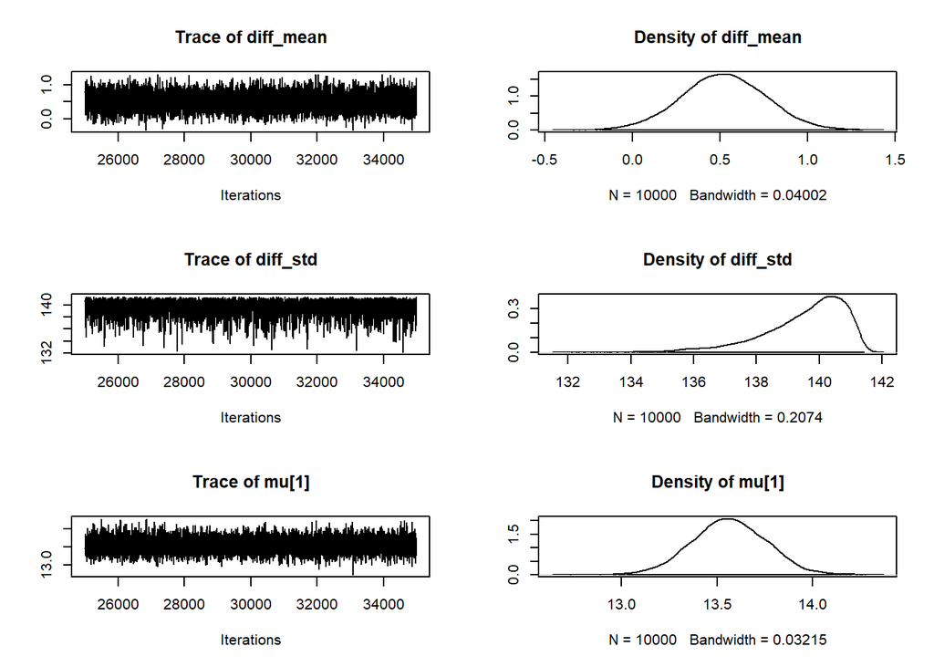

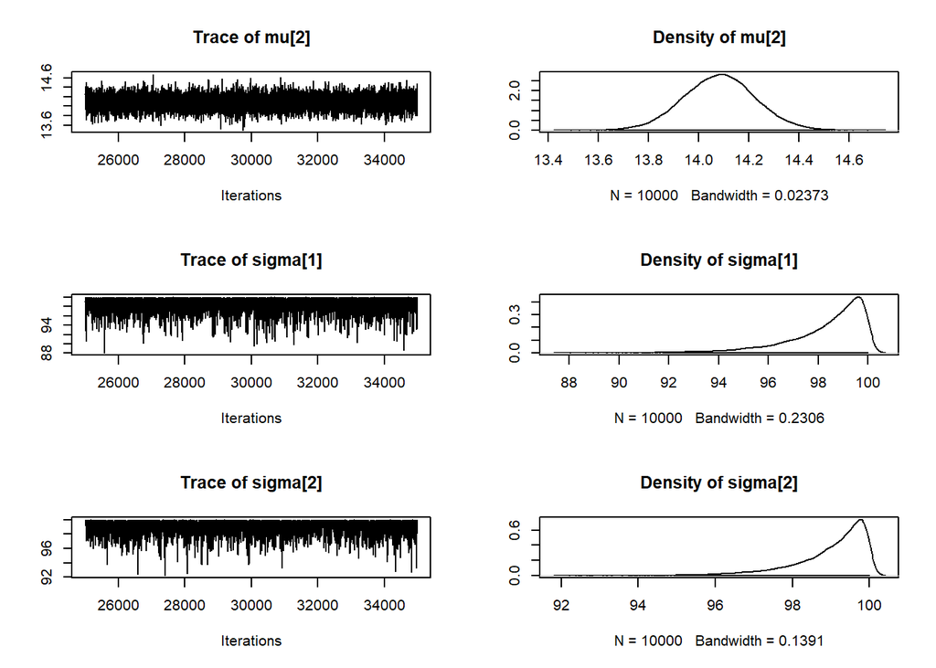

```r
# Plot posterior distributions if needed
plot(samples)
```

```r
set.seed(111)
#### Dichotomous ####
model_odds <- "model{
  ### data model
  for(i in 1:N){
  Y[i] ~ dbin(p[i], 1)
  logit(p[i]) <- beta_0+beta_1*ptype[i]

  }

    OR <-exp(beta_1)
    pos.prob <- step(OR - 2)
    ### prior
    beta_0 ~ dnorm(0,0.0001)
    beta_1 ~ dnorm(0,0.0001)
}"

# Prepare data for JAGS
jags_data <- list(N = nrow(baseline_data),
                  ptype = baseline_data$ptype,
                  Y = NULL)  # We'll update Y for each variable in the loop

# Create an empty list to store samples
samples_odds <- list()

# Loop through each variable
for (variable in c("SH.Ever.Smoked.", "MC.Aspirin", "MC.Stroke", "MC.Diabetes.Mellitus", "MC.HTN", "MC.Coronary.Artery.Disease", "MC.Cancer", "MC.Heart.Attack")) {
  # Update data for each variable
  jags_data$Y <- baseline_data[[variable]]
  jags_data$ptype <- baseline_data$ptype

  # Compile the model
  model.odds <- jags.model(textConnection(model_odds), data = jags_data, n.adapt=1500)

  # Run the model
  update(model.odds, n.iter = 10000)
  samples <- coda.samples(model.odds, variable.names = c('OR','beta_0','beta_1', 'pos.prob'), n.iter = 10000)

  # Store samples
  samples_odds[[variable]] <- samples

  # Summarize posterior distributions
  print(paste("Summary for", variable))
  print(summary(samples))
}
```

```
##
##
## [1] "Summary for SH.Ever.Smoked."
##
## Iterations = 11501:21500
## Thinning interval = 1
## Number of chains = 1
## Sample size per chain = 10000
##
## 1. Empirical mean and standard deviation for each variable,
##    plus standard error of the mean:
##
##             Mean      SD  Naive SE Time-series SE
## OR        0.6178 0.09991 0.0009991       0.002859
## beta_0    0.6081 0.12981 0.0012981       0.003689
## beta_1   -0.4944 0.16028 0.0016028       0.004612
## pos.prob  0.0000 0.00000 0.0000000       0.000000
##
## 2. Quantiles for each variable:
##
##             2.5%     25%     50%     75%   97.5%
## OR        0.4463  0.5482  0.6096  0.6783  0.8402
## beta_0    0.3521  0.5217  0.6076  0.6967  0.8591
## beta_1   -0.8068 -0.6012 -0.4949 -0.3881 -0.1741
## pos.prob  0.0000  0.0000  0.0000  0.0000  0.0000
##
##
##
## [1] "Summary for MC.Aspirin"
##
## Iterations = 11501:21500
## Thinning interval = 1
## Number of chains = 1
## Sample size per chain = 10000
##
## 1. Empirical mean and standard deviation for each variable,
##    plus standard error of the mean:
##
##              Mean     SD Naive SE Time-series SE
## OR        0.74691 0.1146 0.001146       0.003054
```

[output cut: 152 more lines]

```
##    plus standard error of the mean:
##
##             Mean      SD  Naive SE Time-series SE
## OR        0.7155 0.25177 0.0025177      0.0064789
## beta_0   -2.7328 0.25693 0.0025693      0.0063753
## beta_1   -0.3930 0.34121 0.0034121      0.0085426
## pos.prob  0.0008 0.02827 0.0002827      0.0003711
##
## 2. Quantiles for each variable:
##
##             2.5%     25%     50%     75%   97.5%
## OR        0.3431  0.5389  0.6748  0.8448  1.3345
## beta_0   -3.2523 -2.8983 -2.7231 -2.5599 -2.2526
## beta_1   -1.0698 -0.6182 -0.3933 -0.1687  0.2886
## pos.prob  0.0000  0.0000  0.0000  0.0000  0.0000
```

Based on the summary results, the OR, beta0, and beta1 values for SH.Ever.Smoked, MC.Asprin, MC.Stroke, MC.Diabetes.Melitus, MC.HTN, MC.Coronary.Artery.Disease all had 95% confidence intervals that exclude 0, and therefore, can be considered confounding variables.

## Comparing TICS Scores at Baseline

```r
set.seed(111)
model_linear <- "
model {
for (i in 1:N) {
    Y[i] ~ dnorm(mu[i], tau)
    mu[i] <- beta0 + beta_offspring * ptype[i] + beta_age * Age01[i] + beta_bmi * BMI[i] + beta_smoke * SH.Ever.Smoked[i] + beta_aspirin * MC.Aspirin[i] + beta_stroke * MC.Stroke[i] + beta_diabetes * MC.Diabetes.Mellitus[i] + beta_htn * MC.HTN[i] + beta_cad * MC.Coronary.Artery.Disease[i]  # Include other confounders here
}

  # Priors
  beta0 ~ dnorm(0, 0.001)
  beta_offspring ~ dnorm(0, 0.001)
  beta_age ~ dnorm(0, 0.001)
  beta_bmi ~ dnorm(0, 0.001)
  beta_smoke ~ dnorm(0, 0.001)
  beta_aspirin ~ dnorm(0, 0.001)
  beta_stroke ~ dnorm(0, 0.001)
  beta_diabetes ~ dnorm(0, 0.001)
  beta_htn ~ dnorm(0, 0.001)
  beta_cad ~ dnorm(0, 0.001)
  tau ~ dgamma (1,1)

}"


# Calculate the mean BMI
mean_bmi <- mean(baseline_data$BMI, na.rm = TRUE)

# Replace missing BMI values with the mean
baseline_data$BMI[is.na(baseline_data$BMI)] <- mean_bmi

# Prepare data for JAGS
jags_data_linear <- list(
  N = nrow(baseline_data),
  BMI = baseline_data$BMI,
  MC.Aspirin = baseline_data$MC.Aspirin,
  ptype = baseline_data$ptype,
  Age01 = baseline_data$Age01,
  SH.Ever.Smoked = baseline_data$SH.Ever.Smoked.,
  MC.Stroke = baseline_data$MC.Stroke,
  MC.Diabetes.Mellitus = baseline_data$MC.Diabetes.Mellitus,
  MC.HTN = baseline_data$MC.HTN,
  MC.Coronary.Artery.Disease = baseline_data$MC.Coronary.Artery.Disease,
  Y = baseline_data$TICS01
)


# Compile the model
model <- jags.model(textConnection(model_linear), data = jags_data_linear, n.chains = 3)
# Run the model
update(model, 10000)

samples_linear <- coda.samples(model, variable.names = c("beta0", "beta_age", "beta_offspring", "beta_bmi","beta_smoke","beta_aspirin","beta_stroke", "beta_diabetes", "beta_htn", "beta_cad", "sigma"), n.iter = 10000)
# Summarize posterior distributions
print(summary(samples_linear))
```

```
##
## Iterations = 10001:20000
## Thinning interval = 1
## Number of chains = 3
## Sample size per chain = 10000
##
## 1. Empirical mean and standard deviation for each variable,
##    plus standard error of the mean:
##
##                    Mean      SD  Naive SE Time-series SE
## beta0          30.83129 1.71155 0.0098816       0.160491
## beta_age       -0.20873 0.02024 0.0001169       0.001762
## beta_aspirin   -0.04875 0.29625 0.0017104       0.002911
## beta_bmi       -0.05310 0.03242 0.0001872       0.001647
## beta_cad       -0.98159 0.63331 0.0036564       0.005587
## beta_diabetes  -0.69595 0.55622 0.0032113       0.005035
## beta_htn       -0.04278 0.31348 0.0018099       0.002898
## beta_offspring  0.48557 0.30664 0.0017704       0.004065
## beta_smoke      0.03352 0.28866 0.0016666       0.003299
## beta_stroke    -0.95748 0.89495 0.0051670       0.005313
##
## 2. Quantiles for each variable:
##
##                   2.5%      25%      50%      75%    97.5%
## beta0          27.5249 29.60890 30.84555 31.97527 34.18633
## beta_age       -0.2487 -0.22262 -0.20871 -0.19410 -0.17034
## beta_aspirin   -0.6314 -0.24751 -0.04956  0.14947  0.52614
## beta_bmi       -0.1189 -0.07431 -0.05287 -0.03193  0.01016
## beta_cad       -2.2099 -1.40842 -0.98624 -0.55387  0.26673
## beta_diabetes  -1.7755 -1.06693 -0.69788 -0.31910  0.39865
## beta_htn       -0.6547 -0.25335 -0.04164  0.16680  0.57651
## beta_offspring -0.1193  0.28021  0.48584  0.69101  1.09489
## beta_smoke     -0.5321 -0.16036  0.03507  0.22721  0.59939
## beta_stroke    -2.7088 -1.56006 -0.95858 -0.35691  0.81158
```

```r
geweke.diag(samples_linear, frac1 = 0.1, frac2 = 0.5)
```

```
## [[1]]
##
## Fraction in 1st window = 0.1
## Fraction in 2nd window = 0.5
##
##          beta0       beta_age   beta_aspirin       beta_bmi       beta_cad
##        0.06648        0.13900        0.09215       -0.38290        0.05369
##  beta_diabetes       beta_htn beta_offspring     beta_smoke    beta_stroke
##        0.74056       -0.32195       -1.55496       -0.99755        0.48480
##
##
## [[2]]
##
## Fraction in 1st window = 0.1
## Fraction in 2nd window = 0.5
##
##          beta0       beta_age   beta_aspirin       beta_bmi       beta_cad
##        -2.5602         1.4466         0.6042         1.5482        -1.6865
##  beta_diabetes       beta_htn beta_offspring     beta_smoke    beta_stroke
##        -1.3893        -2.5380         0.4181         0.8943        -2.5857
##
##
## [[3]]
##
## Fraction in 1st window = 0.1
## Fraction in 2nd window = 0.5
##
##          beta0       beta_age   beta_aspirin       beta_bmi       beta_cad
##        1.43003       -2.27804        1.40177        0.15842        0.96138
##  beta_diabetes       beta_htn beta_offspring     beta_smoke    beta_stroke
##       -0.02767        0.82426        1.22127       -0.11667        1.14144
```

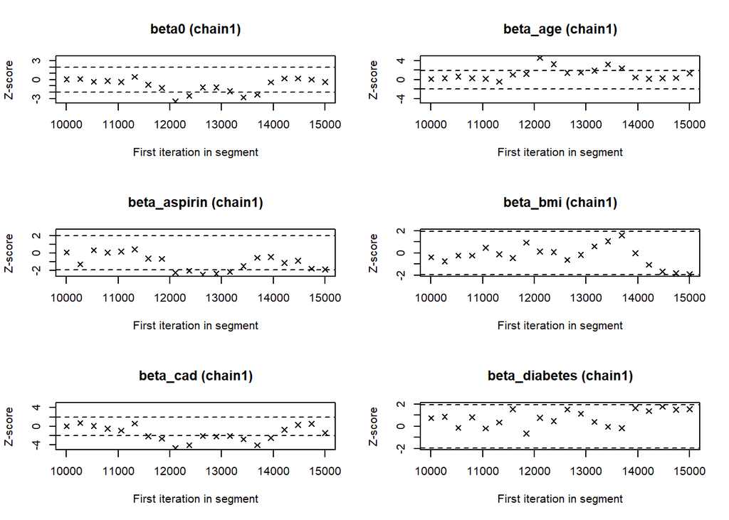

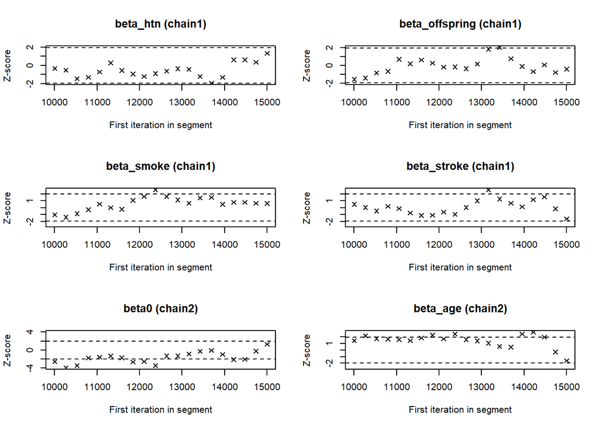

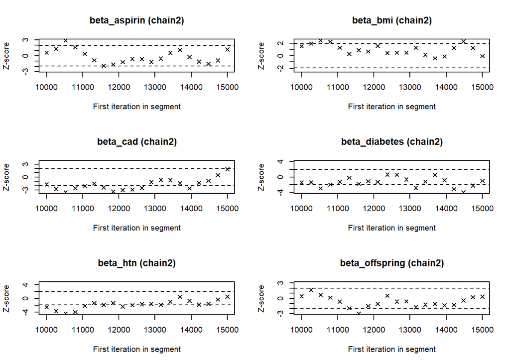

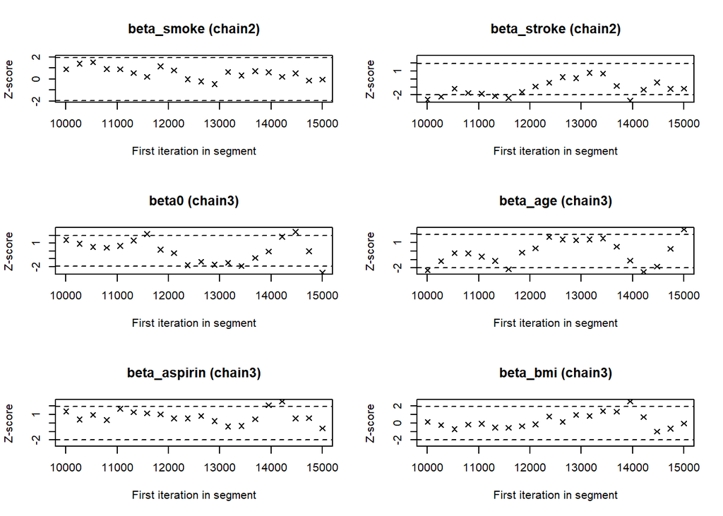

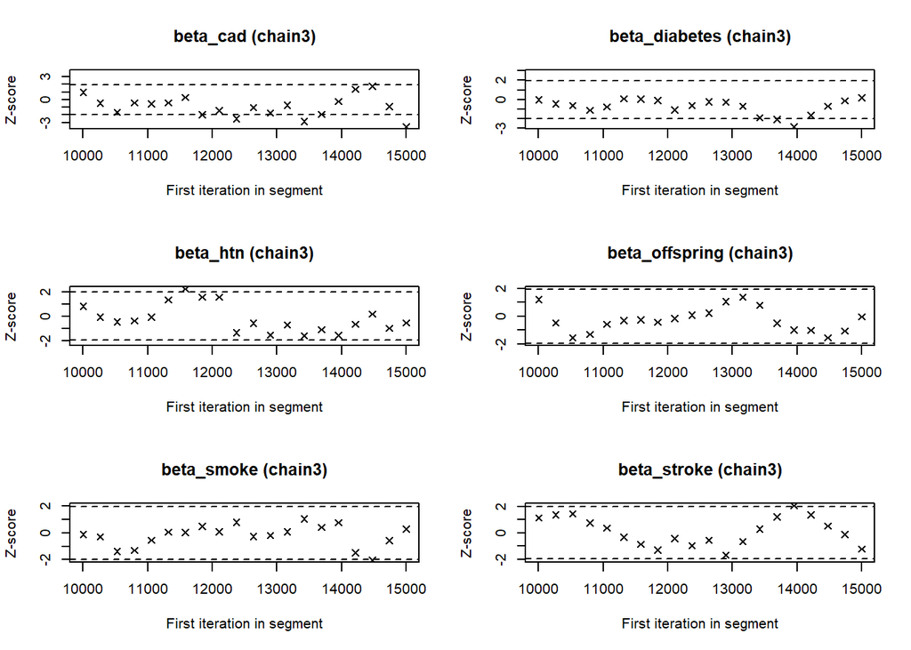

```r
geweke.plot(samples_linear, frac1 = 0.1, frac2 = 0.5)
```

```r
gelman.diag(samples_linear)
```

```
## Potential scale reduction factors:
##
##                Point est. Upper C.I.
## beta0                1.01       1.02
## beta_age             1.01       1.02
## beta_aspirin         1.00       1.00
## beta_bmi             1.00       1.00
## beta_cad             1.00       1.00
## beta_diabetes        1.00       1.00
## beta_htn             1.00       1.00
## beta_offspring       1.00       1.00
## beta_smoke           1.00       1.00
## beta_stroke          1.00       1.00
##
## Multivariate psrf
##
## 1
```

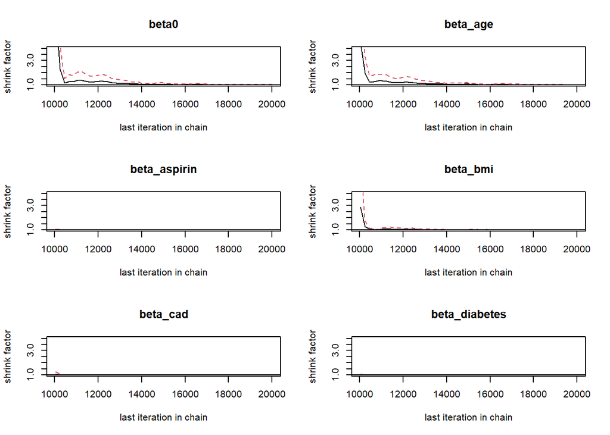

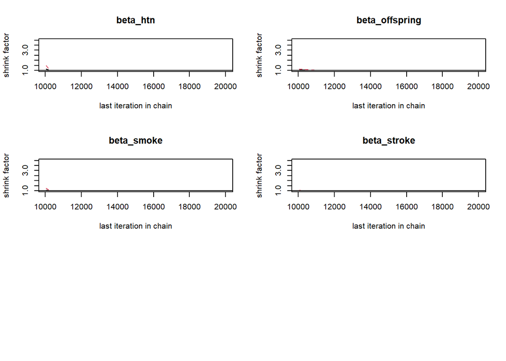

```r
gelman.plot(samples_linear, ylim = c(1, 4))
```

## Rate of Change of TICS:

The aim of this section is to to investigate whether there are differences in the rate of change of TICS between offspring of centenarians and individuals without parental longevity (ptype). We used the longitudinal data set for this, which was first cleaned to remove NA values and recode dichotomous variables. For missing values Age variables, we imputed using the mean values.

```r
# Clean the longitudinal data
tics_clean <- tics.data.2021 %>%
  filter(!is.na(TICS01) & !is.na(TICS02) & !is.na(TICS03) & !is.na(TICS04) & !is.na(TICS05)) %>%
  select(ID, fam.num, ptype, Age.at.Enrollment, Age01, Age02, Age03, Age04, Age05, BMI, SH.Ever.Smoked.,
         MC.Aspirin, MC.Stroke, MC.Diabetes.Mellitus, MC.HTN, MC.Coronary.Artery.Disease,
         MC.Cancer, MC.Heart.Attack, Years.of.Education, TICS01, TICS02, TICS03, TICS04, TICS05)

# Recode "yes" and "no" variables to 1 and 0, handling missing values
tics_clean <- tics_clean %>%
  mutate(SH.Ever.Smoked. = if_else(SH.Ever.Smoked. == "Yes", 1, if_else(SH.Ever.Smoked. == "No", 0, NA_integer_)),
         MC.Aspirin = if_else(MC.Aspirin == "Yes", 1, if_else(MC.Aspirin == "No", 0, NA_integer_)),
         MC.Stroke = if_else(MC.Stroke == "Yes", 1, if_else(MC.Stroke == "No", 0, NA_integer_)),
         MC.Diabetes.Mellitus = if_else(MC.Diabetes.Mellitus == "Yes", 1, if_else(MC.Diabetes.Mellitus == "No", 0, NA_integer_)),
         MC.HTN = if_else(MC.HTN == "Yes", 1, if_else(MC.HTN == "No", 0, NA_integer_)),
         MC.Coronary.Artery.Disease = if_else(MC.Coronary.Artery.Disease == "Yes", 1, if_else(MC.Coronary.Artery.Disease == "No", 0, NA_integer_)),
         MC.Cancer = if_else(MC.Cancer == "Yes", 1, if_else(MC.Cancer == "No", 0, NA_integer_)),
         MC.Heart.Attack = if_else(MC.Heart.Attack == "Yes", 1, if_else(MC.Heart.Attack == "No", 0, NA_integer_)))

# Remove observations where MC.Aspirin is NA
tics_clean <- tics_clean[!is.na(baseline_data$MC.Aspirin), ]

head(tics_clean)
```

```
##   ID fam.num ptype Age.at.Enrollment Age01 Age02 Age03 Age04 Age05      BMI
## 1  1       1     1                64    70    72    74    76    78 22.96386
## 2  2       1     1                70    76    78    80    82    84       NA
## 3  3       1     1                69    74    77    79    81    83 30.58906
## 4  4       1     1                64    69    71    73    75    78 21.99409
## 5  5       1     1                61    67    69    71    73    75 25.55509
## 6  6       2     1                77    82    84    86    88    91 20.17747
##   SH.Ever.Smoked. MC.Aspirin MC.Stroke MC.Diabetes.Mellitus MC.HTN
## 1               0          1         0                    0      1
## 2               0          0         0                    0      1
## 3               0          0         0                    0      1
## 4               0          1         0                    0      1
## 5               0          1         0                    0      0
## 6               1          0         0                    0      0
##   MC.Coronary.Artery.Disease MC.Cancer MC.Heart.Attack Years.of.Education
## 1                          0         1               0               16.0
## 2                          0         0               0               19.0
## 3                          0         1               0               17.0
## 4                          0         1               0               19.0
## 5                          0         0               0               19.5
## 6                          0         1               0               18.0
##   TICS01 TICS02 TICS03 TICS04 TICS05
## 1     12     25     23     19     22
## 2     17     12     13     11     12
## 3     15     12     13     11     16
## 4     11     13     11     12     11
## 5     17     17     16     17     19
## 6     13     18     16     14     18
```

```r
# Impute missing values for Age01 to Age05 with mean age value at each visit
tics_clean[is.na(tics_clean$Age01), "Age01"] <- mean(tics_clean$Age01, na.rm = TRUE)
tics_clean[is.na(tics_clean$Age02), "Age02"] <- mean(tics_clean$Age02, na.rm = TRUE)
tics_clean[is.na(tics_clean$Age03), "Age03"] <- mean(tics_clean$Age03, na.rm = TRUE)
tics_clean[is.na(tics_clean$Age04), "Age04"] <- mean(tics_clean$Age04, na.rm = TRUE)
tics_clean[is.na(tics_clean$Age05), "Age05"] <- mean(tics_clean$Age05, na.rm = TRUE)

# Define the clustering variable
fam.num <- tics_clean$fam.num

# Initialize a vector to store the family index
tics_clean$fam <- NA

# Assign family index based on fam.num
tics_clean$fam[1] <- 1
for (i in 2:nrow(tics_clean)) {
  if (!is.na(tics_clean$fam.num[i]) && !is.na(tics_clean$fam.num[i - 1])) {
    if (tics_clean$fam.num[i] == tics_clean$fam.num[i - 1]) {
      tics_clean$fam[i] <- tics_clean$fam[i - 1]
    } else {
      tics_clean$fam[i] <- tics_clean$fam[i - 1] + 1
    }
  } else {
    tics_clean$fam[i] <- NA
  }
}


# Transform the data from wide to long format
tics_long <- tics_clean %>%
  pivot_longer(cols = starts_with("Age0"), names_to = "Time_Age", values_to = "Age") %>%
  pivot_longer(cols = starts_with("TICS"), names_to = "Time_TICS", values_to = "TICS") %>%
  group_by(ID, Time_Age, Time_TICS) %>%
  slice(1)

tics_long <- tics_long %>%
  mutate(Age_Last_Two = substr(Time_Age, nchar(Time_Age) - 1, nchar(Time_Age)),
         TICS_Last_Two = substr(Time_TICS, nchar(Time_TICS) - 1, nchar(Time_TICS))) %>%
  filter(Age_Last_Two == TICS_Last_Two) %>%
  select(-Age_Last_Two, -TICS_Last_Two)


tics_long <- tics_long %>%
  mutate(Time = as.numeric(substr(Time_Age, nchar(Time_Age), nchar(Time_Age))))

# View the modified data
print(tics_long)
```

```
## # A tibble: 1,530 × 20
## # Groups:   ID, Time_Age, Time_TICS [1,530]
##       ID fam.num ptype Age.at.Enrollment   BMI SH.Ever.Smoked. MC.Aspirin
##    <int>   <int> <int>             <int> <dbl>           <dbl>      <dbl>
##  1     1       1     1                64  23.0               0          1
##  2     1       1     1                64  23.0               0          1
##  3     1       1     1                64  23.0               0          1
##  4     1       1     1                64  23.0               0          1
##  5     1       1     1                64  23.0               0          1
##  6     2       1     1                70  NA                 0          0
##  7     2       1     1                70  NA                 0          0
##  8     2       1     1                70  NA                 0          0
##  9     2       1     1                70  NA                 0          0
## 10     2       1     1                70  NA                 0          0
## # ℹ 1,520 more rows
## # ℹ 13 more variables: MC.Stroke <dbl>, MC.Diabetes.Mellitus <dbl>,
## #   MC.HTN <dbl>, MC.Coronary.Artery.Disease <dbl>, MC.Cancer <dbl>,
## #   MC.Heart.Attack <dbl>, Years.of.Education <dbl>, fam <dbl>, Time_Age <chr>,
## #   Age <dbl>, Time_TICS <chr>, TICS <int>, Time <dbl>
```

```r
# View the transformed data
head(tics_long)
```

```
## # A tibble: 6 × 20
## # Groups:   ID, Time_Age, Time_TICS [6]
##      ID fam.num ptype Age.at.Enrollment   BMI SH.Ever.Smoked. MC.Aspirin
##   <int>   <int> <int>             <int> <dbl>           <dbl>      <dbl>
## 1     1       1     1                64  23.0               0          1
## 2     1       1     1                64  23.0               0          1
## 3     1       1     1                64  23.0               0          1
## 4     1       1     1                64  23.0               0          1
## 5     1       1     1                64  23.0               0          1
## 6     2       1     1                70  NA                 0          0
## # ℹ 13 more variables: MC.Stroke <dbl>, MC.Diabetes.Mellitus <dbl>,
## #   MC.HTN <dbl>, MC.Coronary.Artery.Disease <dbl>, MC.Cancer <dbl>,
## #   MC.Heart.Attack <dbl>, Years.of.Education <dbl>, fam <dbl>, Time_Age <chr>,
## #   Age <dbl>, Time_TICS <chr>, TICS <int>, Time <dbl>
```

```r
tics_long <- tics_long[!is.na(tics_long$fam.num), ]
fam <- unique(tics_long$fam.num[!is.na(tics_long$fam.num)])

# Count the number of unique family IDs
num_unique_families <- length(unique(tics_long$fam.num))
print(num_unique_families)
```

```
## [1] 232
```

We build a hierarchical model where the mean output is a linear regression of ptype, adjusted for all the confounder variables. Here, this is an extra alpha-variable for each family cluster, which was modelled using a normal prior. We found that there were 232 family clusters.

```r
set.seed(111)
# Define the hierarchical model
model_hierarchical <- "
model {
  # Likelihood
  for (i in 1:N) {
    mu[i] <- beta0 + beta_offspring * ptype[i] + beta_age * Age[i] + beta_interaction * Time[i] * ptype[i] + beta_bmi * BMI[i] + beta_smoke * SH.Ever.Smoked[i] + beta_aspirin * MC.Aspirin[i] + beta_stroke * MC.Stroke[i] + beta_diabetes * MC.Diabetes.Mellitus[i] + beta_htn * MC.HTN[i] + beta_cad * MC.Coronary.Artery.Disease[i] + alpha[fam[i]]
    Y[i] ~ dnorm(mu[i], tau)
  }

  # Cluster-level effects
  for (j in 1:J) {
    alpha[j] ~ dnorm(beta0, tau)
  }

  # Priors
  beta0 ~ dnorm(0, 0.001)
  beta_offspring ~ dnorm(0, 0.001)
  beta_age ~ dnorm(0, 0.001)
  beta_interaction ~ dnorm(0, 0.001)
  beta_bmi ~ dnorm(0, 0.001)
  beta_smoke ~ dnorm(0, 0.001)
  beta_aspirin ~ dnorm(0, 0.001)
  beta_stroke ~ dnorm(0, 0.001)
  beta_diabetes ~ dnorm(0, 0.001)
  beta_htn ~ dnorm(0, 0.001)
  beta_cad ~ dnorm(0, 0.001)
  tau ~ dgamma(1, 1)
}
"

# Calculate the mean BMI
mean_bmi <- mean(tics_clean$BMI, na.rm = TRUE)

# Replace missing BMI values with the mean
tics_long$BMI[is.na(tics_long$BMI)] <- mean_bmi

# Calculate the number of unique families
num_unique_families <- length(unique(tics_long$fam))

# Prepare data for JAGS
jags_data_hierarchical <- list(
  N = nrow(tics_long),
  BMI = tics_long$BMI,
  MC.Aspirin = tics_long$MC.Aspirin,
  ptype = tics_long$ptype,
  Age = tics_long$Age,
  Time = tics_long$Time,
  SH.Ever.Smoked = tics_long$SH.Ever.Smoked.,
  MC.Stroke = tics_long$MC.Stroke,
  MC.Diabetes.Mellitus = tics_long$MC.Diabetes.Mellitus,
  MC.HTN = tics_long$MC.HTN,
  MC.Coronary.Artery.Disease = tics_long$MC.Coronary.Artery.Disease,
  fam = tics_long$fam,
  J = num_unique_families,
  Y = tics_long$TICS
)


# Compile the model
model_hierarchical <- jags.model(textConnection(model_hierarchical), data = jags_data_hierarchical, n.adapt = 1500, n.chains = 3)
# Run the model
update(model_hierarchical, 10000)
samples_hierarchical <- coda.samples(model_hierarchical, variable.names = c("beta0", "beta_age", "beta_interaction", "beta_offspring", "beta_bmi", "beta_smoke", "beta_aspirin", "beta_stroke", "beta_diabetes", "beta_htn", "beta_cad"), n.iter = 10000)

# Summarize posterior distributions
print(summary(samples_hierarchical))
```

```
##
## Iterations = 10001:20000
## Thinning interval = 1
## Number of chains = 3
## Sample size per chain = 10000
##
## 1. Empirical mean and standard deviation for each variable,
##    plus standard error of the mean:
##
##                      Mean      SD  Naive SE Time-series SE
## beta0            15.45519 0.95714 0.0055261       0.156811
## beta_age         -0.19402 0.02177 0.0001257       0.004047
## beta_aspirin      0.18909 0.31445 0.0018155       0.007716
## beta_bmi         -0.08545 0.03760 0.0002171       0.004410
## beta_cad         -1.57498 0.82987 0.0047912       0.014246
## beta_diabetes    -1.17475 0.73818 0.0042619       0.015424
## beta_htn          0.45932 0.35303 0.0020382       0.007996
## beta_interaction  0.17613 0.07364 0.0004251       0.004316
## beta_offspring    0.35318 0.42934 0.0024788       0.018013
## beta_smoke        0.77066 0.32886 0.0018987       0.008680
## beta_stroke      -2.57258 1.44277 0.0083298       0.029335
##
## 2. Quantiles for each variable:
##
##                      2.5%      25%      50%      75%    97.5%
## beta0            13.69725 14.79015 15.42007 16.13196 17.35077
## beta_age         -0.23594 -0.21006 -0.19405 -0.17812 -0.15170
## beta_aspirin     -0.42956 -0.02318  0.18933  0.40361  0.80053
## beta_bmi         -0.15671 -0.11146 -0.08661 -0.05767 -0.01399
## beta_cad         -3.21445 -2.13007 -1.57332 -1.02177  0.04346
## beta_diabetes    -2.61777 -1.67138 -1.16814 -0.67637  0.27472
## beta_htn         -0.23072  0.22076  0.45842  0.69715  1.15255
## beta_interaction  0.03169  0.12599  0.17681  0.22665  0.31838
## beta_offspring   -0.45235  0.04980  0.35088  0.65492  1.18356
## beta_smoke        0.10984  0.55049  0.77285  0.99502  1.40523
## beta_stroke      -5.39185 -3.54693 -2.57522 -1.59193  0.26793
```

The output shows a statistically significant negative effect between rate of TICS and age of enrollment, and bmi. Smoking had a small statistically significant positive effect on the outcome. The other variables were found to be insignificant. The interaction term between time and p-type was also found to have a small significant positive effect on the outcome.

```r
gelman.diag(samples_hierarchical) # beta_age, and beta_interaction do not reach convergence
```

```
## Potential scale reduction factors:
##
##                  Point est. Upper C.I.
## beta0                  1.03       1.10
## beta_age               1.03       1.09
## beta_aspirin           1.00       1.01
## beta_bmi               1.01       1.04
## beta_cad               1.00       1.00
## beta_diabetes          1.00       1.00
## beta_htn               1.00       1.01
## beta_interaction       1.01       1.03
## beta_offspring         1.00       1.00
## beta_smoke             1.00       1.01
## beta_stroke            1.00       1.00
##
## Multivariate psrf
##
## 1.03
```

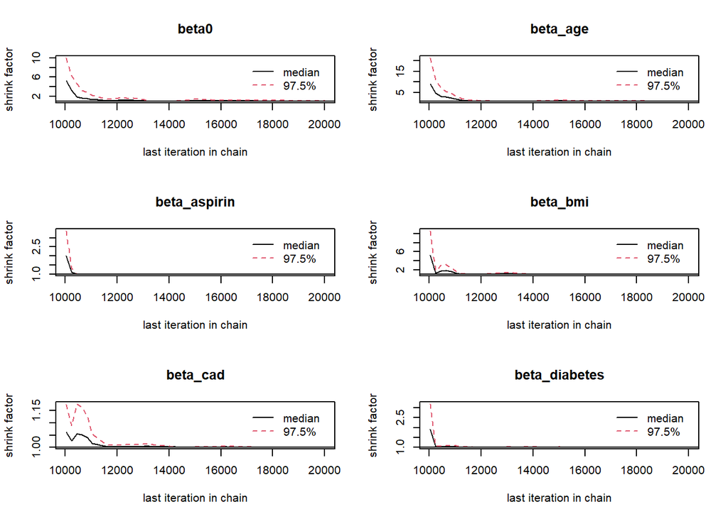

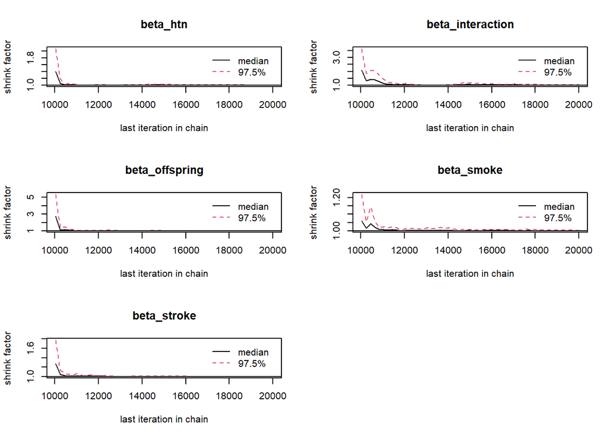

```r
gelman.plot(samples_hierarchical)
```

```r
samples_hierarchical <- coda.samples(model_hierarchical, variable.names = c("beta0", "beta_age", "beta_interaction", "beta_offspring", "beta_bmi", "beta_smoke", "beta_aspirin", "beta_stroke", "beta_diabetes", "beta_htn", "beta_cad"), n.iter = 10000, thin = 8)

gelman.diag(samples_hierarchical) # beta_age, and beta_interaction do not reach convergence
```

```
## Potential scale reduction factors:
##
##                  Point est. Upper C.I.
## beta0                  1.04       1.07
## beta_age               1.06       1.15
## beta_aspirin           1.00       1.00
## beta_bmi               1.03       1.10
## beta_cad               1.00       1.00
## beta_diabetes          1.00       1.01
## beta_htn               1.00       1.00
## beta_interaction       1.02       1.05
## beta_offspring         1.01       1.03
## beta_smoke             1.00       1.01
## beta_stroke            1.00       1.00
##
## Multivariate psrf
##
## 1.04
```

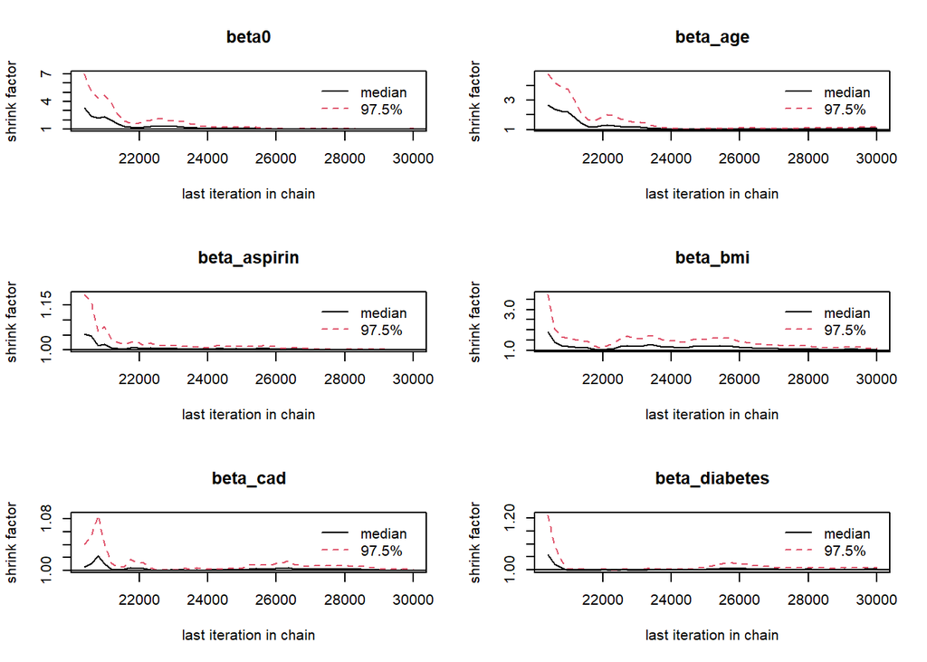

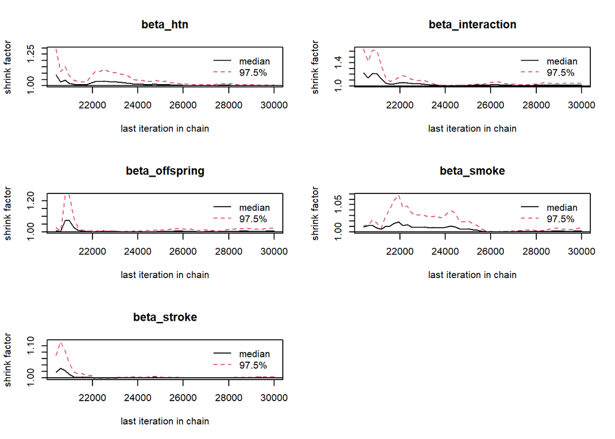

```r
gelman.plot(samples_hierarchical)
```

```r
print(summary(samples_hierarchical))
```

```
##
## Iterations = 20008:30000
## Thinning interval = 8
## Number of chains = 3
## Sample size per chain = 1250
##
## 1. Empirical mean and standard deviation for each variable,
##    plus standard error of the mean:
##
##                      Mean      SD  Naive SE Time-series SE
## beta0            15.79800 0.87702 0.0143217       0.151353
## beta_age         -0.20127 0.01859 0.0003036       0.003158
## beta_aspirin      0.18980 0.31391 0.0051262       0.008154
## beta_bmi         -0.09021 0.04053 0.0006619       0.005034
## beta_cad         -1.51560 0.84975 0.0138764       0.017510
## beta_diabetes    -1.21813 0.73631 0.0120240       0.017236
## beta_htn          0.46749 0.35063 0.0057258       0.008919
## beta_interaction  0.19164 0.07113 0.0011615       0.005490
## beta_offspring    0.32322 0.41590 0.0067916       0.017820
## beta_smoke        0.77891 0.32437 0.0052970       0.008882
## beta_stroke      -2.60175 1.42232 0.0232264       0.029999
##
## 2. Quantiles for each variable:
##
##                     2.5%      25%      50%      75%     97.5%
## beta0            14.1189 15.18980 15.79458 16.41580 17.485196
## beta_age         -0.2400 -0.21391 -0.20055 -0.18884 -0.164845
## beta_aspirin     -0.4212 -0.02256  0.19021  0.39948  0.813166
## beta_bmi         -0.1701 -0.11674 -0.08956 -0.06461 -0.007177
## beta_cad         -3.2056 -2.09274 -1.50694 -0.91605  0.132596
## beta_diabetes    -2.6645 -1.69485 -1.22191 -0.73270  0.250654
## beta_htn         -0.2163  0.23048  0.47142  0.69773  1.173152
## beta_interaction  0.0507  0.14359  0.19176  0.23914  0.332323
## beta_offspring   -0.4909  0.04061  0.32062  0.59144  1.163554
## beta_smoke        0.1397  0.55631  0.77968  1.00129  1.409497
## beta_stroke      -5.3035 -3.57455 -2.60136 -1.65691  0.205608
```

```r
geweke.diag(samples_hierarchical, frac1 = 0.1, frac2 = 0.5)
```

```
## [[1]]
##
## Fraction in 1st window = 0.1
## Fraction in 2nd window = 0.5
##
##            beta0         beta_age     beta_aspirin         beta_bmi
##           1.3293          -1.1208          -1.0544          -0.2237
##         beta_cad    beta_diabetes         beta_htn beta_interaction
##          -0.9061           1.3314          -0.9774           1.8023
##   beta_offspring       beta_smoke      beta_stroke
##          -2.3384          -0.1391          -2.9063
##
##
## [[2]]
##
## Fraction in 1st window = 0.1
## Fraction in 2nd window = 0.5
##
##            beta0         beta_age     beta_aspirin         beta_bmi
##          -1.3088           0.5863           1.6409           1.4879
##         beta_cad    beta_diabetes         beta_htn beta_interaction
##           1.5502           0.9215          -1.4781          -0.3257
##   beta_offspring       beta_smoke      beta_stroke
##          -0.1143           1.4787           0.1776
##
##
## [[3]]
##
## Fraction in 1st window = 0.1
## Fraction in 2nd window = 0.5
##
##            beta0         beta_age     beta_aspirin         beta_bmi
##           2.1450          -2.7790          -1.4941           0.2295
##         beta_cad    beta_diabetes         beta_htn beta_interaction
##           0.3351           0.4005           1.4296           3.5129
##   beta_offspring       beta_smoke      beta_stroke
##          -2.4208          -0.1288          -0.8789
```

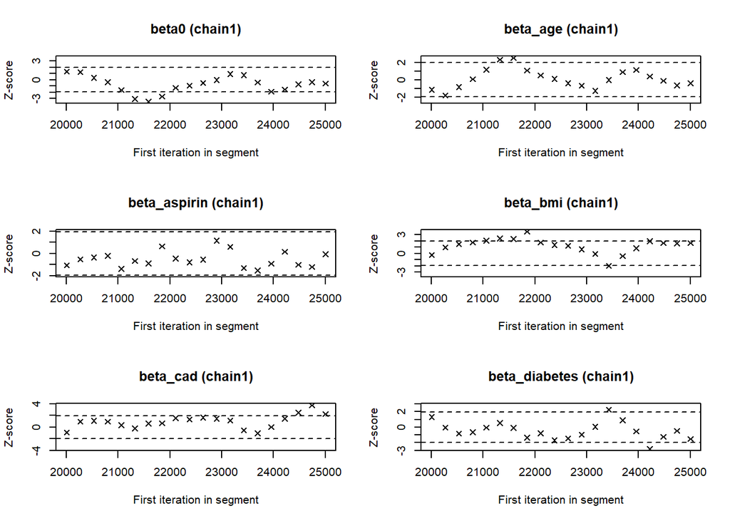

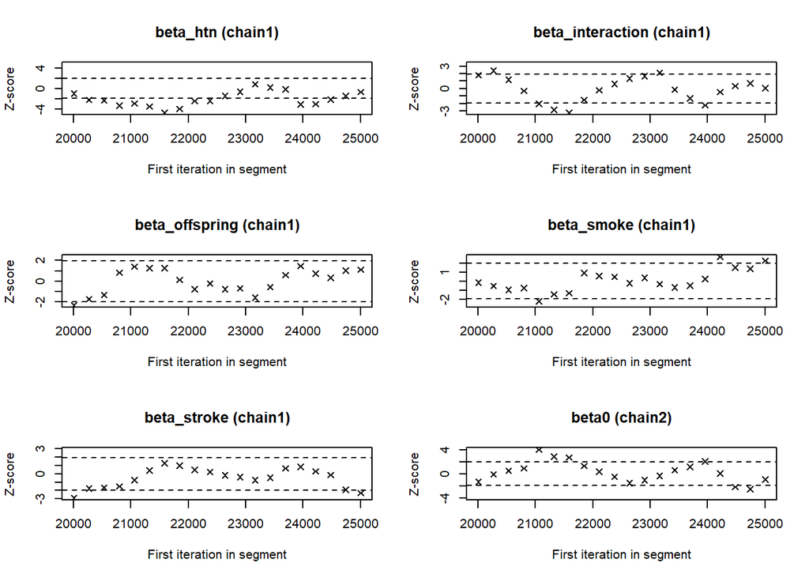

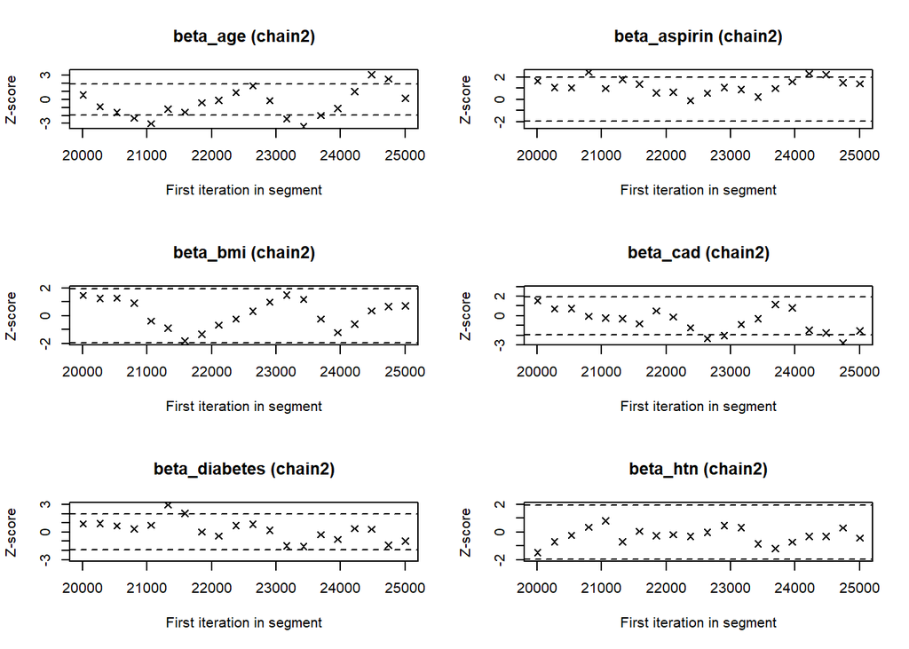

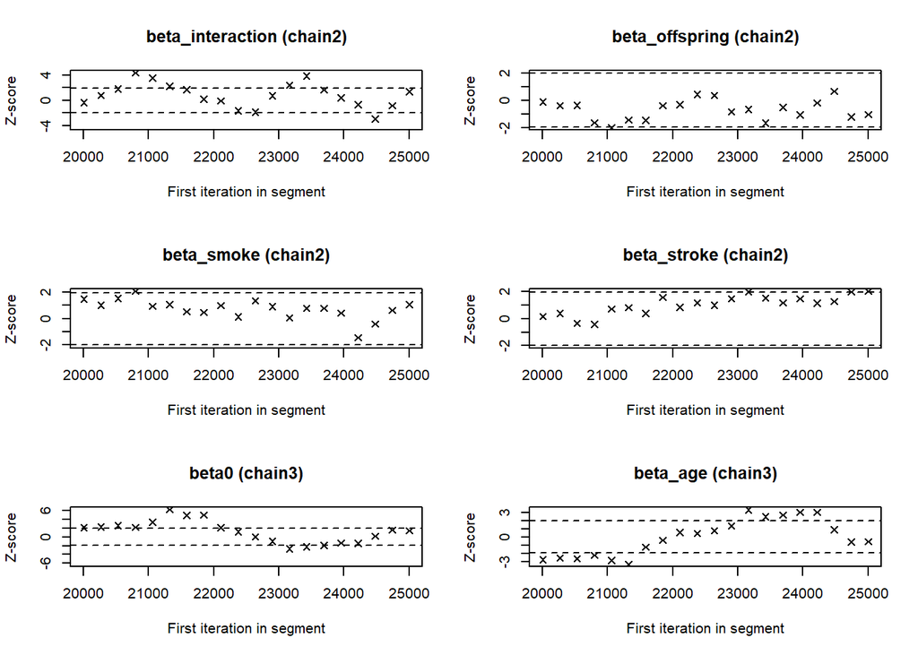

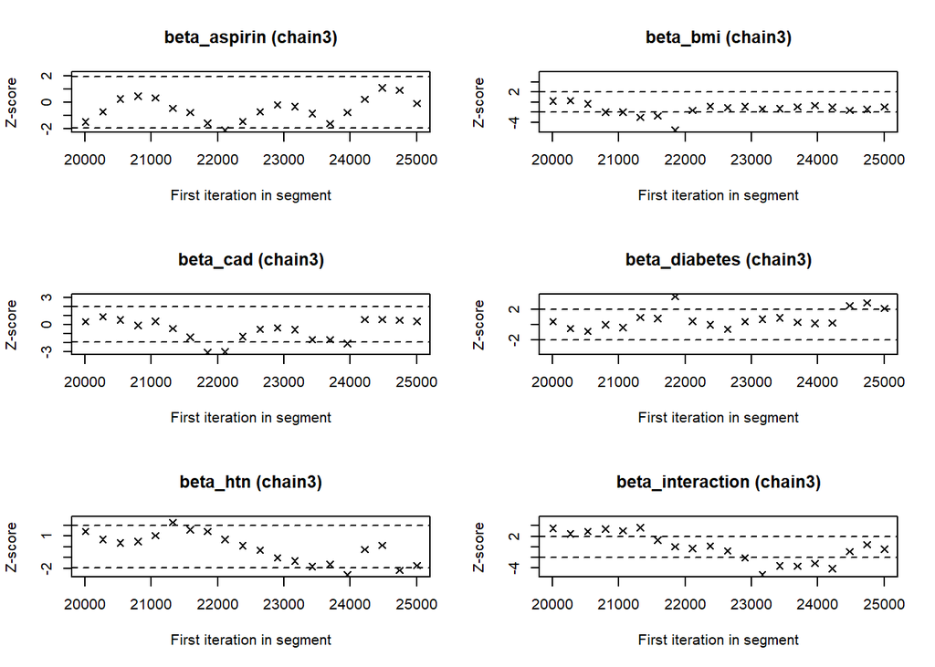

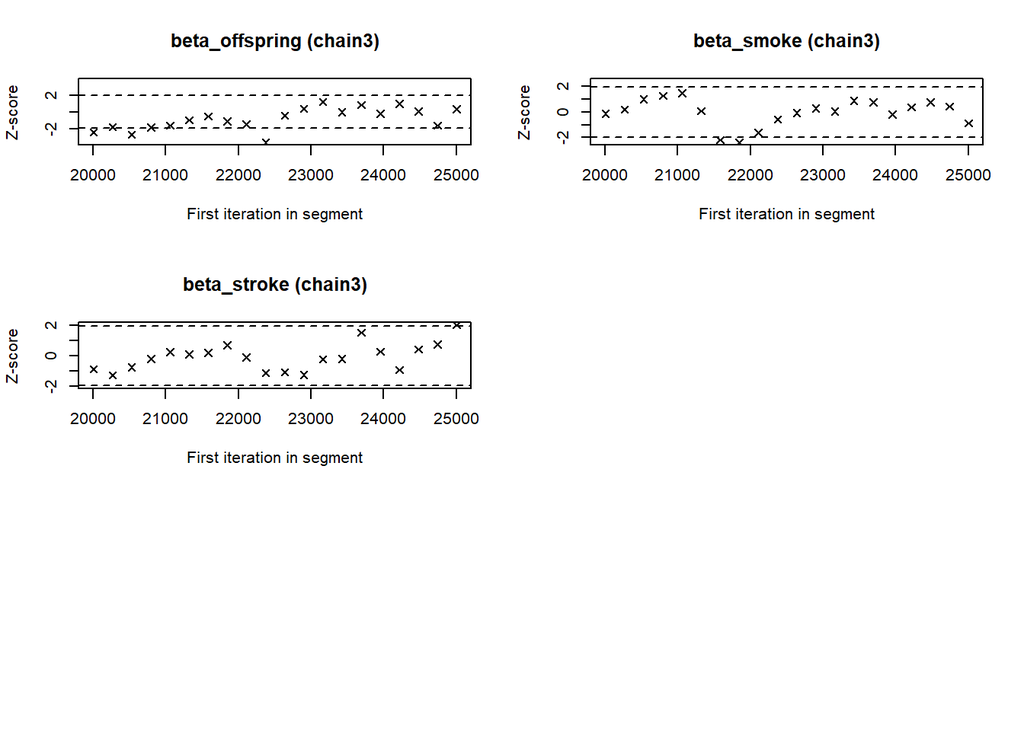

```r
geweke.plot(samples_hierarchical, frac1 = 0.1, frac2 = 0.5)
```

## Missingness and the effect on results:

To understand how missingness impacted our results, we tabulated the missing values and Calculated the proportion of missing values between the control group and the offspring of centennials

```r
summary(tics.data.2021)
```

```
##        ID           fam.num           sex             ptype
##  Min.   :  1.0   Min.   :  1.0   Min.   :0.0000   Min.   :0.0000
##  1st Qu.:213.8   1st Qu.:107.0   1st Qu.:0.0000   1st Qu.:0.0000
##  Median :465.5   Median :201.5   Median :1.0000   Median :1.0000
##  Mean   :455.3   Mean   :214.4   Mean   :0.5787   Mean   :0.6457
##  3rd Qu.:676.8   3rd Qu.:319.0   3rd Qu.:1.0000   3rd Qu.:1.0000
##  Max.   :912.0   Max.   :464.0   Max.   :1.0000   Max.   :1.0000
##
##  Age.at.Enrollment Age.Last.Contact   Deceased              BMI
##  Min.   :39.00     Min.   :53.00    Length:762         Min.   :17.78
##  1st Qu.:66.00     1st Qu.:78.00    Class :character   1st Qu.:24.01
##  Median :71.50     Median :83.00    Mode  :character   Median :26.45
##  Mean   :70.68     Mean   :82.49                       Mean   :27.24
##  3rd Qu.:76.00     3rd Qu.:87.00                       3rd Qu.:29.83
##  Max.   :90.00     Max.   :99.00                       Max.   :51.18
##                    NA's   :1                           NA's   :38
##  SH.Ever.Smoked.     MC.Aspirin         MC.Stroke         MC.Diabetes.Mellitus
##  Length:762         Length:762         Length:762         Length:762
##  Class :character   Class :character   Class :character   Class :character
##  Mode  :character   Mode  :character   Mode  :character   Mode  :character
##
##
##
##
##     MC.HTN          MC.Coronary.Artery.Disease  MC.Cancer
##  Length:762         Length:762                 Length:762
##  Class :character   Class :character           Class :character
##  Mode  :character   Mode  :character           Mode  :character
##
##
##
##
##  MC.Heart.Attack    Years.of.Education     TICS01          Age01
##  Length:762         Min.   : 8.00      Min.   : 2.00   Min.   :46.00
##  Class :character   1st Qu.:14.00      1st Qu.:11.00   1st Qu.:70.00
##  Mode  :character   Median :16.00      Median :14.00   Median :76.00
##                     Mean   :15.79      Mean   :13.91   Mean   :74.94
##                     3rd Qu.:18.00      3rd Qu.:16.00   3rd Qu.:80.00
##                     Max.   :26.00      Max.   :26.00   Max.   :95.00
##                                        NA's   :2
##      TICS02         Age02           TICS03         Age03           TICS04
##  Min.   : 0.0   Min.   :49.00   Min.   : 0.0   Min.   :51.00   Min.   : 0.00
##  1st Qu.:11.0   1st Qu.:72.00   1st Qu.:10.0   1st Qu.:74.00   1st Qu.:11.00
##  Median :14.0   Median :78.00   Median :13.0   Median :80.00   Median :14.00
##  Mean   :14.4   Mean   :76.95   Mean   :13.3   Mean   :78.84   Mean   :13.79
##  3rd Qu.:18.0   3rd Qu.:82.00   3rd Qu.:16.0   3rd Qu.:83.50   3rd Qu.:17.00
##  Max.   :26.0   Max.   :97.00   Max.   :27.0   Max.   :97.00   Max.   :26.00
##  NA's   :74     NA's   :60      NA's   :125    NA's   :111     NA's   :230
##      Age04           TICS05          Age05
##  Min.   :63.00   Min.   : 3.00   Min.   :66.00
##  1st Qu.:76.00   1st Qu.:11.00   1st Qu.:79.00
##  Median :82.00   Median :14.00   Median :83.00
##  Mean   :80.72   Mean   :14.01   Mean   :82.64
##  3rd Qu.:85.00   3rd Qu.:17.00   3rd Qu.:87.00
##  Max.   :99.00   Max.   :27.00   Max.   :98.00
##  NA's   :215     NA's   :451     NA's   :436
```

```r
# Using colSums() and is.na()
missing_values <- colSums(is.na(tics.data.2021))
missing_values
```

```
##                         ID                    fam.num
##                          0                          0
##                        sex                      ptype
##                          0                          0
##          Age.at.Enrollment           Age.Last.Contact
##                          0                          1
##                   Deceased                        BMI
##                          0                         38
##            SH.Ever.Smoked.                 MC.Aspirin
##                          0                          1
##                  MC.Stroke       MC.Diabetes.Mellitus
##                          0                          0
##                     MC.HTN MC.Coronary.Artery.Disease
##                          0                          0
##                  MC.Cancer            MC.Heart.Attack
##                          0                          0
##         Years.of.Education                     TICS01
##                          0                          2
##                      Age01                     TICS02
##                          0                         74
##                      Age02                     TICS03
##                         60                        125
##                      Age03                     TICS04
##                        111                        230
##                      Age04                     TICS05
##                        215                        451
##                      Age05
##                        436
```

```r
# Create a contingency table of ptype and missingness
contingency_table <- table(tics.data.2021$ptype, is.na(tics.data.2021$TICS01))

# Display the contingency table
print(contingency_table)
```

```
##
##     FALSE TRUE
##   0   269    1
##   1   491    1
```

```r
# Calculate proportions of missingness within each level of ptype
prop_missing <- tapply(is.na(tics.data.2021$TICS01), tics.data.2021$ptype, mean)
print(prop_missing)
```

```
##           0           1
## 0.003703704 0.002032520
```

```r
prop_missing <- tapply(is.na(tics.data.2021$TICS02), tics.data.2021$ptype, mean)
print(prop_missing)
```

```
##          0          1
## 0.14444444 0.07113821
```

```r
prop_missing <- tapply(is.na(tics.data.2021$TICS03), tics.data.2021$ptype, mean)
print(prop_missing)
```

```
##         0         1
## 0.2296296 0.1280488
```

```r
prop_missing <- tapply(is.na(tics.data.2021$TICS04), tics.data.2021$ptype, mean)
print(prop_missing)
```

```
##         0         1
## 0.3888889 0.2540650
```

```r
prop_missing <- tapply(is.na(tics.data.2021$TICS05), tics.data.2021$ptype, mean)
print(prop_missing)
```

```
##         0         1
## 0.7037037 0.5304878
```

Missing values for the Age and TICS variables increase with time (from Age01 to Age05, and from TICS01 to TICS05). This can be associated with increasing deaths as time goes by. Additionally, the control group has more missing values than the the offspring of centennials. While there is no direct evidence, this could be due to higher number of deaths in the control population.

It is unclear whether the missing values changed our results. This is a possible drawback of longitudinal data. However, We did perform mean imputation for age and BMI in our analysis to account for the missing values.

## Checking for family-group level interactions

In order to check if groups had significantly different values for rate of TICS, we included an additional interaction term between family groups and time. However, the results show that there was only a small, but significant affect of the family groups on the rate of TICS (beta_interaction2).

```r
set.seed (111)
# Define the hierarchical model
model_hierarchical <- "
model {
  # Likelihood
  for (i in 1:N) {
    mu[i] <- beta0 + beta_offspring * ptype[i] + beta_age * Age[i] +
    beta_interaction * Time[i] * ptype[i] + beta_interaction2 * Time[i] * fam[i] + beta_bmi * BMI[i] + beta_smoke * SH.Ever.Smoked[i] +
    beta_aspirin * MC.Aspirin[i] + beta_stroke * MC.Stroke[i] + beta_diabetes * MC.Diabetes.Mellitus[i] +
    beta_htn * MC.HTN[i] + beta_cad * MC.Coronary.Artery.Disease[i] + alpha[fam[i]]
    Y[i] ~ dnorm(mu[i], tau)
  }

  # Cluster-level effects
  for (j in 1:J) {
    alpha[j] ~ dnorm(beta0, tau)
  }

  # Priors
  beta0 ~ dnorm(0, 0.001)
  beta_offspring ~ dnorm(0, 0.001)
  beta_age ~ dnorm(0, 0.001)
  beta_interaction ~ dnorm(0, 0.001)
  beta_interaction2 ~ dnorm (0, 0.001)
  beta_bmi ~ dnorm(0, 0.001)
  beta_smoke ~ dnorm(0, 0.001)
  beta_aspirin ~ dnorm(0, 0.001)
  beta_stroke ~ dnorm(0, 0.001)
  beta_diabetes ~ dnorm(0, 0.001)
  beta_htn ~ dnorm(0, 0.001)
  beta_cad ~ dnorm(0, 0.001)
  tau ~ dgamma(1, 1)
}
"

# Calculate the mean BMI
mean_bmi <- mean(tics_clean$BMI, na.rm = TRUE)

# Replace missing BMI values with the mean
tics_long$BMI[is.na(tics_long$BMI)] <- mean_bmi

# Calculate the number of unique families
num_unique_families <- length(unique(tics_long$fam))

# Prepare data for JAGS
jags_data_hierarchical <- list(
  N = nrow(tics_long),
  BMI = tics_long$BMI,
  MC.Aspirin = tics_long$MC.Aspirin,
  ptype = tics_long$ptype,
  Age = tics_long$Age,
  Time = tics_long$Time,
  SH.Ever.Smoked = tics_long$SH.Ever.Smoked.,
  MC.Stroke = tics_long$MC.Stroke,
  MC.Diabetes.Mellitus = tics_long$MC.Diabetes.Mellitus,
  MC.HTN = tics_long$MC.HTN,
  MC.Coronary.Artery.Disease = tics_long$MC.Coronary.Artery.Disease,
  fam = tics_long$fam,
  J = num_unique_families,
  Y = tics_long$TICS
)


# Compile the model
model_hierarchical <- jags.model(textConnection(model_hierarchical), data = jags_data_hierarchical, n.adapt = 1500, n.chains = 3)
# Run the model
update(model_hierarchical, 10000)
samples_hierarchical <- coda.samples(model_hierarchical, variable.names = c("beta0", "beta_age", "beta_interaction", "beta_interaction2", "beta_offspring", "beta_bmi", "beta_smoke", "beta_aspirin", "beta_stroke", "beta_diabetes", "beta_htn", "beta_cad"), n.iter = 5000, thin=8)

# Summarize posterior distributions
print(summary(samples_hierarchical))
```

```
##
## Iterations = 10008:15000
## Thinning interval = 8
## Number of chains = 3
## Sample size per chain = 625
##
## 1. Empirical mean and standard deviation for each variable,
##    plus standard error of the mean:
##
##                        Mean        SD  Naive SE Time-series SE
## beta0             15.084452 0.7003246 1.617e-02       0.127594
## beta_age          -0.173435 0.0167174 3.861e-04       0.003022
## beta_aspirin       0.183196 0.3140063 7.252e-03       0.011162
## beta_bmi          -0.096721 0.0395485 9.133e-04       0.006703
## beta_cad          -1.642630 0.8521962 1.968e-02       0.024264
## beta_diabetes     -1.119270 0.7271552 1.679e-02       0.023087
## beta_htn           0.394780 0.3496658 8.075e-03       0.012317
## beta_interaction   0.268815 0.0780066 1.801e-03       0.003835
## beta_interaction2 -0.001048 0.0003852 8.897e-06       0.000020
## beta_offspring    -0.077081 0.4532289 1.047e-02       0.027481
## beta_smoke         0.817997 0.3269862 7.551e-03       0.012145
## beta_stroke       -2.565100 1.4347609 3.313e-02       0.040620
##
## 2. Quantiles for each variable:
##
##                        2.5%       25%       50%        75%      97.5%
## beta0             13.634823 14.597772 15.097248 15.5628321 16.5699685
## beta_age          -0.207519 -0.184357 -0.173946 -0.1613557 -0.1427697
## beta_aspirin      -0.443253 -0.024217  0.185304  0.3954856  0.7600669
## beta_bmi          -0.169492 -0.125293 -0.097129 -0.0715624 -0.0118900
## beta_cad          -3.309201 -2.209298 -1.653731 -1.0584359 -0.0336937
## beta_diabetes     -2.485624 -1.608634 -1.132827 -0.6391250  0.3017509
## beta_htn          -0.280862  0.160977  0.393487  0.6243909  1.0813687
## beta_interaction   0.116669  0.217094  0.268369  0.3211049  0.4232416
## beta_interaction2 -0.001826 -0.001307 -0.001047 -0.0007788 -0.0003111
## beta_offspring    -0.954616 -0.396715 -0.088301  0.2424787  0.8040756
## beta_smoke         0.187221  0.597813  0.828569  1.0488611  1.4392692
## beta_stroke       -5.361067 -3.524487 -2.571838 -1.5666898  0.2563138
```